# Scott

Topics that will be discussed in this summary report for Scott County are

- Demographic Characteristics
  - Population growth from 1970 to 2020;
  - population density
  - sex, race, and age
  - educational level of the adult population
  - housing characteristics in terms of age of the housing stock and type of tenure
- Economic Characteristics
  - family income, household income, per capita income,
  - poverty status of families;
  - employment classification according to industry;
  - labor force by place of work and commuting patterns;

For more details on the data used, please see the Data Description tab.

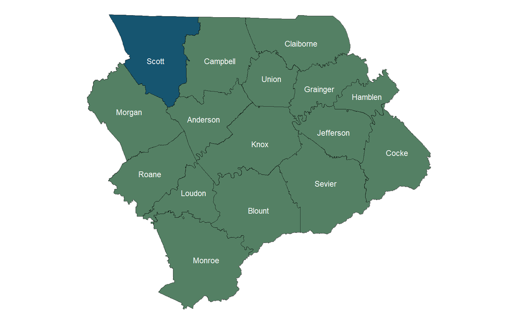

**Population and Growth**

| Place | 1970 | 1980 | 1990 | 2000 | 2010 | 2020 | Change 1970-1980 | Change 1980-1990 | Change 1990-2000 | Change 2000-2010 | Change 2010-2020 |
| --- | --- | --- | --- | --- | --- | --- | --- | --- | --- | --- | --- |
| Scott County | 14762 | 19259 | 18358 | 21127 | 22228 | 21850 | 4497 | -901 | 2769 | 1101 | -378 |
| Huntsville |  | 519 | 660 | 981 | 1248 | 1270 |  | 141 | 321 | 267 | 22 |
| Oneida | 2602 | 3275 | 3502 | 3615 | 3752 | 3787 | 673 | 227 | 113 | 137 | 35 |
| Winfield |  |  | 564 | 911 | 967 | 947 |  |  | 347 | 56 | -20 |

[interactive chart not shown]

IPUMS NHGIS, University of Minnesota, www.nhgis.org

**Population Density**

| Place | Area | Population Density |
| --- | --- | --- |
| Scott County | 533.1028802492879 | 40.98646023030784 |
| Huntsville | 4.050426413904717 | 313.547234345553 |
| Oneida | 9.530268482928731 | 397.3655104033568 |
| Winfield | 6.721709809127895 | 140.8867723974041 |

[interactive chart not shown]

source: U. S. Census Bureau *Decennial Census: Redistricting Data (PL 94-171)*, 2020, accessed June 2, 2026, http://api.census.gov/data/2020/dec/pl.

**Population Descriptions**

| Place | Year | Race Category | Number of People | Percentage of People |
| --- | --- | --- | --- | --- |
| Scott County | 2020 | Black | 47 | 0.001687369857112084 |
| Scott County | 2020 | Other | 752 | 0.02699791771379335 |
| Scott County | 2020 | White | 21051 | 0.7557621885546062 |
| Huntsville | 2020 | Black | 4 | 0.0001436059452861348 |
| Huntsville | 2020 | Other | 23 | 0.0008257341853952754 |
| Huntsville | 2020 | White | 1243 | 0.0446255474976664 |
| Oneida | 2020 | Black | 16 | 0.0005744237811445394 |
| Oneida | 2020 | Other | 176 | 0.006318661592589933 |
| Oneida | 2020 | White | 3595 | 0.1290658433259137 |
| Winfield | 2020 | Black | 1 | 3.590148632153371e-05 |

[output cut: 2 more lines]

| Place | Sex | Age Range | Year | Number of People | Percentage of People |
| --- | --- | --- | --- | --- | --- |
| Scott County | Female | 10 to 14 years | 2020 | 810 | 0.02858151023288638 |
| Scott County | Female | 15 to 19 years | 2020 | 696 | 0.02455892731122089 |
| Scott County | Female | 20 to 24 years | 2020 | 601 | 0.02120677487649965 |
| Scott County | Female | 25 to 29 years | 2020 | 710 | 0.02505292872265349 |
| Scott County | Female | 30 to 34 years | 2020 | 606 | 0.02138320395201129 |
| Scott County | Female | 35 to 39 years | 2020 | 765 | 0.02699364855328158 |
| Scott County | Female | 40 to 44 years | 2020 | 661 | 0.02332392378263938 |
| Scott County | Female | 45 to 49 years | 2020 | 707 | 0.02494707127734651 |
| Scott County | Female | 5 to 9 years | 2020 | 578 | 0.02039520112914608 |
| Scott County | Female | 50 to 54 years | 2020 | 732 | 0.02582921665490473 |

[output cut: 134 more lines]

[interactive chart not shown]

source: U. S. Census Bureau *Decennial Census: Redistricting Data (PL 94-171)*, 2020, accessed June 2, 2026, http://api.census.gov/data/2020/dec/pl.

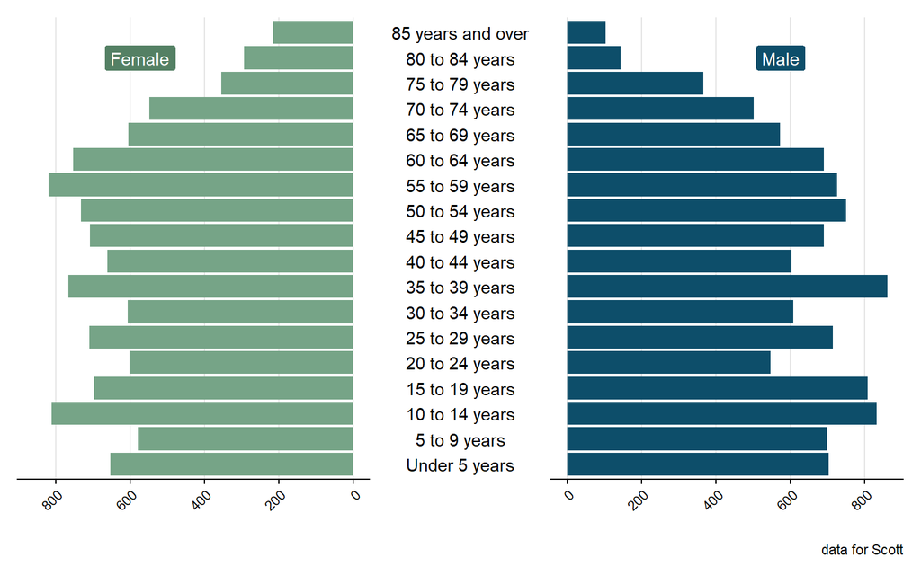

source: U. S. Census Bureau *American Community Survey 5-Year Estimates: Comparison Profiles 5-Year*, 2020, accessed June 2, 2026, http://api.census.gov/data/2020/acs/acs5.

**Education**

| Place | Level of Education | Year | Number of People | Percentage of People |
| --- | --- | --- | --- | --- |
| Scott County | 9th to 12th Grade, No Diploma | 2010 | 1912 | 0.1018809612617893 |
| Scott County | Associate's degree | 2010 | 860 | 0.04582511855917302 |
| Scott County | Bachelor's degree | 2010 | 918 | 0.04891564981083817 |
| Scott County | Graduate or Professional Degree | 2010 | 538 | 0.02866734161027335 |
| Scott County | Less Than 9th Grade | 2010 | 1734 | 0.0923962274204721 |
| Scott County | Some College, No Degree | 2010 | 2117 | 0.1128043906857782 |
| Scott County | Total | 2010 | 14750 | 0.7859540683113977 |
| Scott County | 9th to 12th Grade, No Diploma | 2020 | 1700 | 0.087687625728581 |
| Scott County | Associate's degree | 2020 | 923 | 0.04760922267498839 |
| Scott County | Bachelor's degree | 2020 | 792 | 0.04085211739825657 |

[output cut: 46 more lines]

[interactive chart not shown]

source: U. S. Census Bureau *American Community Survey 5-Year Estimates: Comparison Profiles 5-Year*, 2020, accessed June 2, 2026, http://api.census.gov/data/2020/acs/acs5.

**Housing Units by Year of Construction**

| Place | Year | 1939 or earlier | 1940-1959 | 1960-1979 | 1980 to 1989 | 1990 to 1999 | 2000 to 2004 | 2005 or later | 2000 to 2009 | 2010 or later | Total |
| --- | --- | --- | --- | --- | --- | --- | --- | --- | --- | --- | --- |
| Scott County | 2010 | 622 | 1310 | 2314 | 1699 | 2922 | 758 | 165 |  |  | 9790 |
| Scott County | 2020 | 468 | 825 | 2090 | 1847 | 2282 |  |  | 2016 | 507 | 10035 |
| Huntsville | 2010 | 37 | 80 | 112 | 167 | 128 | 24 | 0 |  |  | 548 |
| Oneida | 2010 | 45 | 216 | 592 | 347 | 593 | 114 | 10 |  |  | 1917 |
| Winfield | 2010 | 23 | 23 | 131 | 56 | 164 | 26 | 17 |  |  | 440 |
| Huntsville | 2020 | 20 | 85 | 197 | 129 | 89 |  |  | 80 | 17 | 617 |
| Oneida | 2020 | 235 | 159 | 348 | 499 | 247 |  |  | 171 | 225 | 1884 |
| Winfield | 2020 | 20 | 29 | 68 | 138 | 117 |  |  | 104 | 24 | 500 |

[interactive chart not shown]

source: U. S. Census Bureau *Decennial Census: Redistricting Data (PL 94-171)*, 2020, accessed June 2, 2026, http://api.census.gov/data/2020/dec/pl.

**Housing Units by Type of Tenure**

| Place | Year | Own | Rent | Total |
| --- | --- | --- | --- | --- |
| Scott County | 2010 | 6379 | 2238 | 8617 |
| Scott County | 2020 | 6152 | 2473 | 8625 |
| Huntsville | 2010 | 229 | 259 | 488 |
| Oneida | 2010 | 1000 | 700 | 1700 |
| Winfield | 2010 | 275 | 122 | 397 |
| Huntsville | 2020 | 205 | 307 | 512 |
| Oneida | 2020 | 859 | 770 | 1629 |
| Winfield | 2020 | 309 | 147 | 456 |

[interactive chart not shown]

source: U. S. Census Bureau *Decennial Census: Redistricting Data (PL 94-171)*, 2020, accessed June 2, 2026, http://api.census.gov/data/2020/dec/pl.

**Income Comparison**

| Place | Year | Median Family Income | Median Household Income | Per Capita Income |
| --- | --- | --- | --- | --- |
| Scott County | 2020 | 42254 | 37135 | 19970 |
| Huntsville | 2020 | 30929 | 23611 | 12704 |
| Oneida | 2020 | 35775 | 25075 | 20119 |
| Winfield | 2020 | 38533 | 35259 | 18425 |

[interactive chart not shown]

source: U. S. Census Bureau *Decennial Census: Redistricting Data (PL 94-171)*, 2020, accessed June 2, 2026, http://api.census.gov/data/2020/dec/pl.

**Povery Status**

| Place | Year | Above Poverty | Below Poverty |
| --- | --- | --- | --- |
| Scott County | 2020 | 4856 | 1046 |
| Huntsville | 2020 | 160 | 89 |
| Oneida | 2020 | 663 | 391 |
| Winfield | 2020 | 263 | 42 |

[interactive chart not shown]

source: U. S. Census Bureau *American Community Survey 5-Year Estimates: Comparison Profiles 5-Year*, 2020, accessed June 2, 2026, http://api.census.gov/data/2020/acs/acs5.

**Poverty Status by Family Type**

| Place | Poverty Status | Family Type | Number of Families | Year | Percentage of Families |
| --- | --- | --- | --- | --- | --- |
| Scott County | Above Poverty | All Families | 4856 | 2020 | 0.6466045272969374 |
| Scott County | Above Poverty | Female Householder | 664 | 2020 | 0.08841544607190413 |
| Scott County | Above Poverty | Female Householder with related children | 435 | 2020 | 0.05792276964047936 |
| Scott County | Below Poverty | All Families | 1046 | 2020 | 0.1392809587217044 |
| Scott County | Below Poverty | Female Householder | 555 | 2020 | 0.07390146471371505 |
| Scott County | Below Poverty | Female Householder with related children | 493 | 2020 | 0.06564580559254328 |
| Huntsville | Above Poverty | All Families | 160 | 2020 | 0.02130492676431425 |
| Huntsville | Above Poverty | Female Householder | 59 | 2020 | 0.007856191744340879 |
| Huntsville | Above Poverty | Female Householder with related children | 40 | 2020 | 0.005326231691078562 |
| Huntsville | Below Poverty | All Families | 89 | 2020 | 0.0118508655126498 |

[output cut: 14 more lines]

[interactive chart not shown]

source: U. S. Census Bureau *American Community Survey 5-Year Estimates: Comparison Profiles 5-Year*, 2020, accessed June 2, 2026, http://api.census.gov/data/2020/acs/acs5.

**Employment by Industry**

| Place | Industry | Year | Number of Jobs | Percentage of Jobs |
| --- | --- | --- | --- | --- |
| Huntsville | Construction | 2010 | 55 | 0.1325301204819277 |
| Huntsville | Construction | 2020 | 24 | 0.02083333333333333 |
| Huntsville | Educational Services, And Health Care And Social Assistance | 2010 | 121 | 0.291566265060241 |
| Huntsville | Educational Services, And Health Care And Social Assistance | 2020 | 83 | 0.0720486111111111 |
| Huntsville | Manufacturing | 2010 | 66 | 0.1590361445783132 |
| Huntsville | Manufacturing | 2020 | 61 | 0.05295138888888889 |
| Huntsville | Other Industries | 2010 | 102 | 0.2457831325301205 |
| Huntsville | Other Industries | 2020 | 141 | 0.1223958333333333 |
| Huntsville | Retail Trade | 2010 | 32 | 0.07710843373493977 |
| Huntsville | Retail Trade | 2020 | 32 | 0.02777777777777778 |

[output cut: 38 more lines]

[interactive chart not shown]

source: U. S. Census Bureau *American Community Survey 5-Year Estimates: Comparison Profiles 5-Year*, 2020, accessed June 2, 2026, http://api.census.gov/data/2020/acs/acs5.

**Employment by Industry (Historical)**

| Place | Year | Industry | Number of Jobs | Percentage of Jobs |
| --- | --- | --- | --- | --- |
| Huntsville | 2010 | Agriculture, Forestry, Fishing And Hunting, And Mining | 5 | 0.0004751948298802509 |
| Huntsville | 2010 | Construction | 55 | 0.00522714312868276 |
| Huntsville | 2010 | Manufacturing | 66 | 0.006272571754419312 |
| Huntsville | 2010 | Other | 23 | 0.002185896217449154 |
| Huntsville | 2010 | Professional Services | 141 | 0.01340049420262308 |
| Huntsville | 2010 | Public Administration | 32 | 0.003041246911233606 |
| Huntsville | 2010 | Trade, Finance, Insurance &amp; Real Estate | 93 | 0.008838623835772667 |
| Huntsville | 2020 | Agriculture, Forestry, Fishing And Hunting, And Mining | 0 | 0 |
| Huntsville | 2020 | Construction | 24 | 0.0023619722468261 |
| Huntsville | 2020 | Manufacturing | 61 | 0.00600334612734967 |

[output cut: 46 more lines]

**Labor Force by Place of Work**

| Place | Year | Work Out Of State | Work Out of County of Residence | Work in County of Residence |
| --- | --- | --- | --- | --- |
| Scott County | 2020 | 565 | 1615 | 5817 |
| Huntsville | 2020 | 13 | 45 | 297 |
| Oneida | 2020 | 149 | 117 | 830 |
| Winfield | 2020 | 53 | 87 | 294 |

[interactive chart not shown]

source: U. S. Census Bureau *American Community Survey 5-Year Estimates: Comparison Profiles 5-Year*, 2020, accessed June 2, 2026, http://api.census.gov/data/2020/acs/acs5.

**Commuting Patterns**

| Home County | Year | Number of Jobs | Percentage of Jobs |
| --- | --- | --- | --- |
| Scott | 2010 | 4205 | 0.4039773273129023 |
| Scott | 2020 | 3869 | 0.3716975694110866 |
| Campbell | 2020 | 191 | 0.01834950523585359 |
| Morgan | 2010 | 155 | 0.01489095974637333 |
| Morgan | 2020 | 130 | 0.01248919204534537 |
| Campbell | 2010 | 127 | 0.01220097992122202 |
| Knox | 2020 | 114 | 0.01095206071668748 |
| Knox | 2010 | 102 | 0.009799212220194062 |
| Anderson | 2020 | 76 | 0.007301373811124988 |
| Anderson | 2010 | 61 | 0.005860313190508214 |

[output cut: 3 more lines]

| Work County | Year | Number of Jobs | Percentage of Jobs |
| --- | --- | --- | --- |
| Scott | 2010 | 4205 | 0.4039773273129023 |
| Scott | 2020 | 3869 | 0.3716975694110866 |
| Knox | 2020 | 819 | 0.07868190988567586 |
| Knox | 2010 | 736 | 0.07070804111826304 |
| Anderson | 2020 | 523 | 0.05024498030550485 |
| Anderson | 2010 | 344 | 0.03304832356614468 |
| Campbell | 2020 | 254 | 0.02440195984244404 |
| Morgan | 2020 | 236 | 0.02267268709770391 |
| Campbell | 2010 | 229 | 0.02200019214141608 |
| Morgan | 2010 | 171 | 0.01642809107503122 |

[output cut: 3 more lines]

[interactive chart not shown]

source: U. S. Census Bureau *Tn_od_main_JT00_2020*, LEHD Origin-Destination Employment Statistics, 8.3, 2020, accessed June 2, 2026, https://lehd.ces.census.gov/data/lodes/.

## References

Bureau, U. S. Census. *American Community Survey 5-Year Estimates: Comparison Profiles 5-Year*. 2020. Accessed June 2, 2026. http://api.census.gov/data/2020/acs/acs5.

Bureau, U. S. Census. *Decennial Census: Redistricting Data (PL 94-171)*. 2020. Accessed June 2, 2026. http://api.census.gov/data/2020/dec/pl.

Bureau, U. S. Census. *Tn_od_main_JT00_2020*. LEHD Origin-Destination Employment Statistics, 8.3. 2020. Accessed June 2, 2026. https://lehd.ces.census.gov/data/lodes/.